# Project Notebook: Hate Crimes in the United States

This notebook analyzes how hate crime legislation impacts crime rates and victim protections nationwide, and identifies factors influencing policy efficacy across different political climates.

**Research Question:** How does the presence and implementation of hate crime legislation affect hate crime rates and victim protections across politically diverse states, and what factors contribute to policy efficacy regardless of a given state’s political climate?

**Why is this question is important?** Hate crimes cause significant violence and harm, making it critical to assess how effective hate crime legislation is in preventing such incidents. We aimed to determine whether stricter legislation leads to lower crime rates or if a different approach is needed due to the failure of current laws, helping inform whether states should strengthen or change their policies.

## Part 1: EDA

### 1.1. EDA & Data Cleaning

```python
# Loading in the necessary packages

import pandas as pd
import numpy as np

# Data Visualization & EDA Packages
import matplotlib.pyplot as plt
import seaborn.objects as so
import seaborn as sns
import folium
from folium.plugins import TimeSliderChoropleth
import json
import os
from branca.colormap import linear
import branca.colormap

# Modeling Tools
from sklearn.model_selection import train_test_split
from sklearn.metrics import accuracy_score, classification_report
from sklearn.metrics import confusion_matrix
from sklearn.compose import ColumnTransformer
from sklearn.preprocessing import OneHotEncoder, OrdinalEncoder, StandardScaler, LabelEncoder
from sklearn.pipeline import Pipeline
from sklearn.preprocessing import TargetEncoder
from feature_engine.encoding import CountFrequencyEncoder
from sklearn.utils.class_weight import compute_class_weight

# Models
from statsmodels.discrete.count_model import ZeroInflatedNegativeBinomialP
from sklearn.linear_model import LogisticRegression
from sklearn.multioutput import MultiOutputClassifier
from sklearn.ensemble import RandomForestClassifier

!pip install xgboost==3.0.0
from xgboost import XGBClassifier
```

[output not shown]

#### Data Applicability

The `hate_crimes` dataset provides comprehensive details on hate crime incidents across the U.S., including location, offense type, and offender/victim characteristics. It also includes features of varrying granularity, which are optimal for our study of hate crimes on the state level.

```python
# Reading in the Data

hate_crimes = pd.read_csv("hate_crime.csv", dtype = {"OFFENDER_ETHNICITY": str,
                                                      "DATE_YEAR": int})
```

#### Data Cleaning

```python
# Data Cleaning

# Dropping columns with a high missing value count (missing 99% of their data)
dropped = ["PUB_AGENCY_UNIT",
           "ADULT_VICTIM_COUNT",
           "JUVENILE_VICTIM_COUNT",
           "ADULT_OFFENDER_COUNT",
           "JUVENILE_OFFENDER_COUNT",
           "OFFENDER_ETHNICITY"]
hate_crimes = hate_crimes.drop(dropped, axis = 1)

# Dropping rows with missing data from the remaining columns
hate_crimes = hate_crimes.dropna()

# Dropping US territories and non-state locations (Guam, Federal State, DC))
hate_crimes = hate_crimes[hate_crimes["STATE_ABBR"] != "GM"]
hate_crimes = hate_crimes[hate_crimes["STATE_ABBR"] != "FS"]
hate_crimes = hate_crimes[hate_crimes["STATE_ABBR"] != "DC"]
```

### 1.2. Correlation Between Variables

We decided to contruct correlation matricies in order to understand how some variables relate to each other. We wanted to examine if legislation level was correlated in any way with hate crime counts or if specific crime types were correlated with increased or decreased hate crime counts.

```python
# 1. Mapping `BIAS_DESC` to hate crime biases

bias_map = {
    "Race/Color" : ['Anti-Black or African American',
                    'Anti-White',
                    'Anti-Asian',
                    'Anti-Hispanic or Latino',
                    'Anti-Other Race/Ethnicity/Ancestry',
                    'Anti-Multiple Races, Group',
                    'Anti-American Indian or Alaska Native',
                    'Anti-Native Hawaiian or Other Pacific Islander',
                    'Anti-Arab'],
    "National Origin" : [],
    "Religion" : ['Anti-Jewish',
                  'Anti-Protestant',
                  'Anti-Other Religion',
                  'Anti-Islamic (Muslim)',
                  'Anti-Catholic',
                  'Anti-Multiple Religions, Group',
                  'Anti-Atheism/Agnosticism',
                  "Anti-Jehovah's Witness",
                  'Anti-Mormon',
                  'Anti-Buddhist',
                  'Anti-Sikh',
                  'Anti-Other Christian',
                  'Anti-Hindu',
                  'Anti-Eastern Orthodox (Russian, Greek, Other)'],
    "Sexual Orientation" : ['Anti-Gay (Male)',
                            'Anti-Heterosexual',
                            'Anti-Lesbian (Female)',
                            'Anti-Lesbian, Gay, Bisexual, or Transgender (Mixed Group)',
                            'Anti-Bisexual'],
    "Gender/Sex" : ['Anti-Female',
                    'Anti-Male'],
    "Gender Identity" : ['Anti-Gender Non-Conforming',
                         'Anti-Transgender'],
    "Disability" : ['Anti-Physical Disability',
                    'Anti-Mental Disability']}

# 2. Mapping 'STATE_NAME' based on the extent of hate crime legislation

legislation_map = {
    'South Carolina': 'none',
    'Wyoming': 'none',
    'Alabama': 'some',
    'Arkansas': 'some',
    'Idaho': 'some',
    'Kentucky': 'some',
    'Michigan': 'some',
    'Mississippi': 'some',
    'Montana': 'some',
    'North Carolina': 'some',
    'North Dakota': 'some',
    'Ohio': 'some',
    'Oklahoma': 'some',
    'Pennsylvania': 'some',
    'South Dakota': 'some',
    'West Virginia': 'some',
    'Alaska': 'extensive',
    'Arizona': 'extensive',
    'California': 'extensive',
    'Colorado': 'extensive',
    'Connecticut': 'extensive',
    'Delaware': 'extensive',
    'Florida': 'extensive',
    'Georgia': 'extensive',
    'Hawaii': 'extensive',
    'Illinois': 'extensive',
    'Indiana': 'extensive',
    'Iowa': 'extensive',
    'Kansas': 'extensive',
    'Louisiana': 'extensive',
    'Maine': 'extensive',
    'Maryland': 'extensive',
    'Massachusetts': 'extensive',
    'Minnesota': 'extensive',
    'Missouri': 'extensive',
    'Nebraska': 'extensive',
    'Nevada': 'extensive',
    'New Hampshire': 'extensive',
    'New Jersey': 'extensive',
    'New Mexico': 'extensive',
    'New York': 'extensive',
    'Oregon': 'extensive',
    'Rhode Island': 'extensive',
    'Tennessee': 'extensive',
    'Texas': 'extensive',
    'Utah': 'extensive',
    'Vermont': 'extensive',
    'Virginia': 'extensive',
    'Washington': 'extensive',
    'Wisconsin': 'extensive'
}

# Create a `Bias_Category`column with values mapped to the bias categories in the "BIAS_DESC" column
def map_bias_category(bias_desc):
    for category, bias_list in bias_map.items():
        if bias_desc in bias_list:
            return category

hate_crimes["Bias_Category"] = hate_crimes["BIAS_DESC"].map(map_bias_category)
hate_crimes["Legislation_Level"] = hate_crimes["STATE_NAME"].map(legislation_map)


# 3. Adding columns for each type of bias category covered in state legislation

# Hate Crime Legislaion by State Data Table
data = {
    'State': [
        'Alabama', 'Alaska', 'Arizona', 'Arkansas', 'California', 'Colorado', 'Connecticut',
        'Delaware', 'District of Columbia', 'Florida', 'Georgia', 'Hawaii', 'Idaho', 'Illinois',
        'Indiana', 'Iowa', 'Kansas', 'Kentucky', 'Louisiana', 'Maine', 'Maryland', 'Massachusetts',
        'Michigan', 'Minnesota', 'Mississippi', 'Missouri', 'Montana', 'Nebraska', 'Nevada',
        'New Hampshire', 'New Jersey', 'New Mexico', 'New York', 'North Carolina', 'North Dakota',
        'Ohio', 'Oklahoma', 'Oregon', 'Pennsylvania', 'Rhode Island', 'South Carolina', 'South Dakota',
        'Tennessee', 'Texas', 'Utah', 'Vermont', 'Virginia', 'Washington', 'West Virginia',
        'Wisconsin', 'Wyoming'
    ],
    'Race/Color': [
        True, True, True, False, True, True, True, True, True, True, True, True, True, True,
        True, True, True, True, True, True, True, True, True, True, True, True, True, True, True,
        True, True, True, True, True, True, True, True, True, True, True, False, True, True, True,
        True, True, True, True, True, True, False
    ],
    'National Origin': [
        True, True, True, False, True, True, True, True, True, True, True, True, True, True,
        True, True, True, True, True, True, True, True, True, True, True, True, True, True, True,
        True, True, True, True, True, True, True, True, True, True, True, False, True, True, True,
        True, True, True, True, True, True, False
    ],
    'Religion': [
        True, True, True, False, True, True, True, True, True, True, True, True, True, True,
        True, True, True, True, True, True, True, True, True, True, True, True, True, True, True,
        True, True, True, True, True, True, True, True, True, True, True, False, True, True, True,
        True, True, True, True, True, True, False
    ],
    'Sexual Orientation': [
        False, False, True, True, True, True, True, True, True, True, True, True, False, True,
        True, True, True, False, True, True, True, True, False, True, False, True, True, True, True,
        True, True, True, True, False, False, False, False, True, False, True, False, False, True,
        True, True, True, True, True, False, True, False
    ],
    'Gender/Sex': [
        False, True, True, True, True, False, True, True, True, False, True, True, False, True,
        False, True, True, False, True, True, True, True, True, True, True, True, True, True, True,
        True, True, True, True, True, True, True, False, True, False, True, False, False, True,
        True, True, True, True, True, True, True, False
    ],
    'Gender Identity': [
        False, False, False, False, False, False, True, True, True, False, True, True, False, False,
        False, False, False, False, False, False, False, True, False, False, False, False, False, False,
        True, True, True, True, True, False, False, False, False, True, False, False, False, False,
        False, False, True, True, True, True, False, False, False
    ],
    'Disability': [
        True, True, True, False, True, True, True, True, True, True, True, True, False, True,
        True, True, True, False, True, True, True, True, False, True, False, True, True, False, True,
        True, True, True, True, False, False, False, True, True, False, True, False, False, True,
        True, True, True, True, True, False, True, False
    ]
}

# Dataframe describing a state's hate crime legislation accoring to the mapping above
hc_leg_state = pd.DataFrame(data)


model3DF = hate_crimes.copy()

categories = {
    "Violent Crime": [
        "Aggravated Assault", "Simple Assault", "Intimidation", "Murder and Nonnegligent Manslaughter",
        "Negligent Manslaughter", "Kidnapping/Abduction", "Robbery", "Rape", "Sodomy",
        "Sexual Assault With An Object", "Fondling", "Incest", "Statutory Rape", "Purse-snatching"
    ],
    "Property Crime": [
        "Burglary/Breaking & Entering", "Destruction/Damage/Vandalism of Property", "Arson",
        "Theft From Motor Vehicle", "Theft From Building", "Motor Vehicle Theft", "Shoplifting",
        "Theft of Motor Vehicle Parts or Accessories", "All Other Larceny", "Pocket-picking",
        "Theft From Coin-Operated Machine or Device", "Stolen Property Offenses"
    ],
    "Drug Offense": [
        "Drug/Narcotic Violations", "Drug Equipment Violations"
    ],
    "Weapon Offense": [
        "Weapon Law Violations"
    ],
    "Sex Offense": [
        "Rape", "Fondling", "Sodomy", "Incest", "Statutory Rape", "Pornography/Obscene Material"
    ],
    "Fraud": [
        "Credit Card/Automated Teller Machine Fraud", "False Pretenses/Swindle/Confidence Game",
        "Welfare Fraud", "Embezzlement", "Counterfeiting/Forgery", "Wire Fraud"
    ],
    "Impersonation": [
        "Impersonation"
    ],
    "Extortion/Blackmail": [
        "Extortion/Blackmail"
    ],
    "Other": [
        "Prostitution", "Not Specified"
    ]
}

# Bias Category
def map_bias_to_category(bias_desc):
    categories = set()
    for bias in bias_desc.split(';'):
        for category, biases in bias_map.items():
            if any(b in bias for b in biases):
                categories.add(category)
    return ';'.join(sorted(categories)) if categories else 'Unknown'

offense_to_category = {}
for cat, offenses in categories.items():
    for o in offenses:
        offense_to_category[o] = cat

def map_offense_type(offense_str):
    offense_list = [o.strip() for o in offense_str.split(";")]
    category_set = set()
    for offense in offense_list:
        category_set.add(offense_to_category.get(offense, "Other"))
    return ";".join(sorted(category_set))

model3DF['OFFENSE_TYPE'] = model3DF['OFFENSE_NAME'].apply(map_offense_type)
model3DF["bias_category"] = model3DF['BIAS_DESC'].apply(map_bias_to_category)
model3DF["legislation"] = model3DF['STATE_NAME'].map(legislation_map)

# map victim type
# Define mapping for individual types only
base_type_map = {
    "Individual": "Individual",
    "Religious Organization": "Religious Org",
    "Society/Public": "Society/Public",
    "Business": "Business",
    "Government": "Government",
    "Other": "Other",
    "Unknown": "Unknown",
    "Financial Institution": "Financial Institution",
    "Law Enforcement Officer": "Law Enforcement"
}

def normalize_victim_types(victim_str):
    if pd.isnull(victim_str):
        return "Unknown"
    parts = [v.strip() for v in victim_str.split(";")]
    mapped_parts = [base_type_map.get(p, p) for p in parts]
    return ";".join(sorted(set(mapped_parts)))

# Apply to your DataFrame
model3DF["VICTIM_CATEGORY"] = model3DF["VICTIM_TYPES"].apply(normalize_victim_types)
```

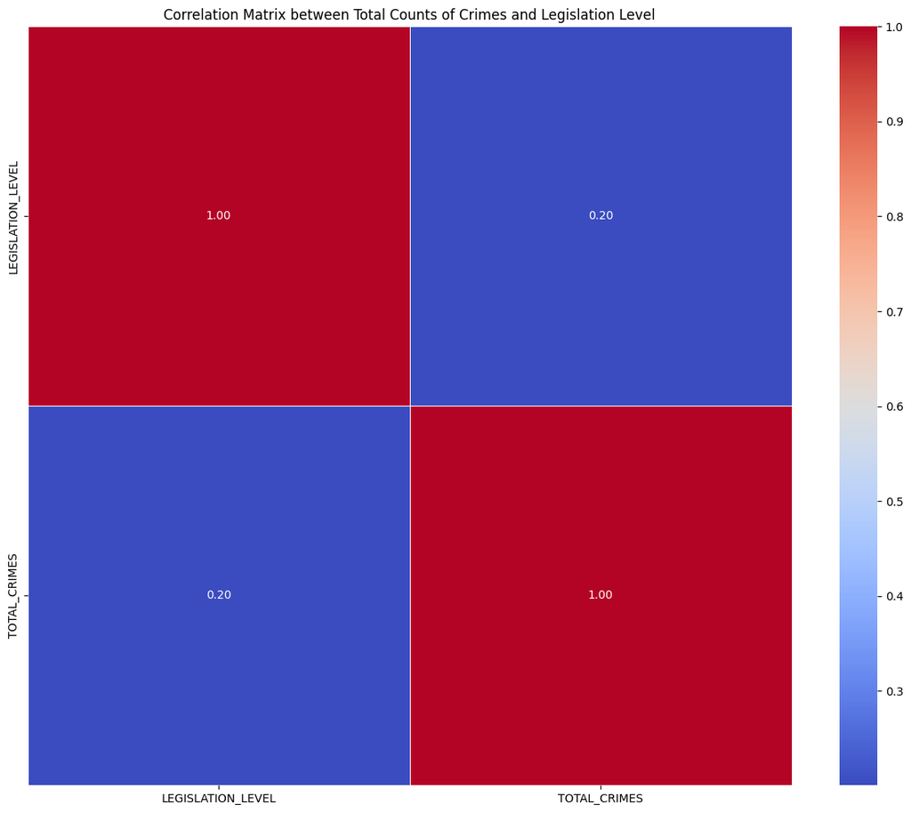

```python
# Step 1: Aggregate total crime counts per state per year
state_crime_counts = hate_crimes.groupby(["STATE_NAME"])["INCIDENT_ID"].count().reset_index()
state_crime_counts.rename(columns={"INCIDENT_ID": "TOTAL_CRIMES"}, inplace=True)
# Step 2: Map state legislation levels
state_crime_counts["LEGISLATION_LEVEL"] = state_crime_counts["STATE_NAME"].map(legislation_map)

# Step 3: Encode legislation levels numerically
legislation_encoding = {"none": 0, "some": 1, "extensive": 2}
state_crime_counts["LEGISLATION_LEVEL"] = state_crime_counts["LEGISLATION_LEVEL"].map(legislation_encoding)

# Step 4: Compute correlation matrix
correlation_matrix = state_crime_counts[["LEGISLATION_LEVEL", "TOTAL_CRIMES"]].corr()

# Display correlation matrix
import seaborn as sns
plt.figure(figsize=(15, 12))
sns.heatmap(correlation_matrix, annot=True, cmap='coolwarm', fmt=".2f", linewidths=.5)
plt.title("Correlation Matrix between Total Counts of Crimes and Legislation Level")
plt.show()
```

**Legislation Level**

Correlation between LEGISLATION_LEVEL and TOTAL_CRIMES: The correlation coefficient is 0.20. This indicates a weak positive correlation between the legislation level and the total number of crimes. There can be a mutual causation here: a state needs to have some legislations so they would record the hate crimes incidents; at the same time, as there are more hate crimes in a state, the state may pass more legislations protecting different groups.

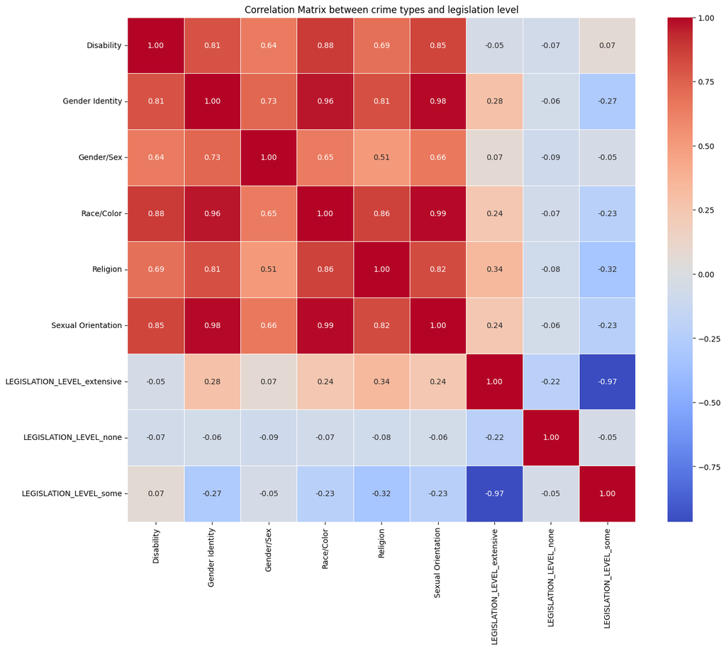

```python
hate_crimes_copy = hate_crimes.copy()
def map_bias_category(bias_desc):
    for category, bias_list in bias_map.items():
        if bias_desc in bias_list:
            return category
hate_crimes_copy["Bias_Category"] = hate_crimes_copy["BIAS_DESC"].map(map_bias_category)
hate_crimes_copy["LEGISLATION_LEVEL"] = hate_crimes_copy["STATE_NAME"].map(legislation_map)
hate_crimes_copy = hate_crimes_copy[['STATE_NAME','Bias_Category', 'LEGISLATION_LEVEL']]

# Step 1: Group the data by 'STATE_NAME' and 'Bias_Category' to get the total incidents per category per state
total_incidents_by_category = hate_crimes_copy.groupby(['STATE_NAME', 'Bias_Category']).size().reset_index(name='Total_Incidents')
# Step 2: One-hot encode the 'LEGISLATION_LEVEL'
legislation_level_dummies = pd.get_dummies(hate_crimes_copy[['STATE_NAME', 'LEGISLATION_LEVEL']], columns=['LEGISLATION_LEVEL'])

# Step 3: Merge the one-hot encoded legislation level with the total incidents by category data
merged_data = pd.merge(total_incidents_by_category, legislation_level_dummies, on='STATE_NAME', how='left')
# Step 4: Pivot the data so that each row represents a state and each column represents a 'Bias_Category'
total_incidents_pivot = merged_data.pivot_table(index='STATE_NAME',
                                               columns='Bias_Category',
                                               values='Total_Incidents',
                                               aggfunc='sum',
                                               fill_value=0)
# Step 5: Merge the one-hot encoded legislation level columns with the total incidents pivot table
final_data = pd.merge(total_incidents_pivot, legislation_level_dummies, on='STATE_NAME', how='left')
final_data_cleaned = final_data.drop(columns=['STATE_NAME']).astype(int)
# Step 6: Compute the correlation matrix between the total incidents and the legislation level
crime_types_legislation_correlation_matrix = final_data_cleaned.corr()
plt.figure(figsize=(15, 12))
sns.heatmap(crime_types_legislation_correlation_matrix, annot=True, cmap='coolwarm', fmt=".2f", linewidths=.5)
plt.title("Correlation Matrix between crime types and legislation level")
plt.show()
```

**Crime Types:**

- The crime types (Disability, Gender Identity, Gender/Sex, Race/Color, Religion, Sexual Orientation) are positively correlated with each other, indicating that they tend to occur together or are related in some way. The high positive correlations among Disability, Gender Identity, Gender/Sex, Race/Color, Religion, and Sexual Orientation suggest that these groups may face similar challenges or systemic issues that lead to higher crime rates against them. This could indicate underlying societal biases or discrimination that needs to be addressed.

**General Analysis:**

- The positive correlations with extensive legislation suggest that higher numbers of incidents might encourage more extensive legislation. This indicates that legislation is responsive to the needs highlighted by the incidence of crimes. Also, it may indicate that more legislations makes the recording process of hate crimes more effective and regulated so we can see more records. Therefore, we think there are some looping effects that are important here.

### 1.3. Data Visualizations

#### 1.3.1. Number of Hate Crimes per State per Year (Time Series Choropleth Map)

The purpose of this visualization is to understand how hate crime counts per state change in relation to time. This is relevant to our question because it enables analysis of changing legislation and how impactful that legislation is in decreasing hate crime counts across the states.

```python
# Method:

# 1. Group data by state and year to get the count of hate crimes that took place so that we can visualize these numbers relative to other states and relative to other years within a specific state
# 2. Create a time series choropleth to visualize these changes in numbers over time

state = hate_crimes.groupby(["STATE_ABBR","DATA_YEAR"])["TOTAL_OFFENDER_COUNT"].count().reset_index()
state.replace("NB", "NE", inplace=True) #Dataset had Nebraska abbreviated as NB but geojson had it as NE

## Building a time-series choropleth, each of the steps in this cell are adapted from
## https://python-visualization.github.io/folium/latest/user_guide/plugins/timeslider_choropleth.html

colormap = linear.Reds_04.scale(-100,200)
n_periods, n_sample = 27, 27
datetime_index = pd.date_range("1993-1-1", periods=n_periods, freq="AS")
dt_index_epochs = datetime_index.astype("int64") // 10 ** 9
dt_index = dt_index_epochs.astype("U10")

styledata = {}

for abbr in state["STATE_ABBR"]:
    df = pd.DataFrame(
        {
            "color": np.random.normal(size=n_periods),
            "opacity": np.random.normal(size=n_periods),
        },
        index=dt_index,
    )
    df = df.cumsum()
    df.sample(n_sample, replace=False).sort_index()
    styledata[abbr] = df

max_color, min_color, max_opacity, min_opacity = 0, 0, 5, 5

for state, data in styledata.items():
    max_color = max(max_color, data["color"].max())
    min_color = min(max_color, data["color"].min())
    max_opacity = max(max_color, data["opacity"].max())
    max_opacity = min(max_color, data["opacity"].max())

def norm(x):
    return (x - x.min()) / (x.max() - x.min())


for state, data in styledata.items():
    data["color"] = data["color"].apply(colormap)
    data["opacity"] = norm(data["opacity"]) + 0.5

styledict = {
    str(state): data.to_dict(orient="index") for state, data in styledata.items()
}

usa_map = folium.Map(location=(39.8283, -98.5795), zoom_start = 3)
us_states = os.path.join('us-states.json')
geo_json_data = json.load(open(us_states))
#init_timestamp = list(styledict.values())[0].keys()[0]


TimeSliderChoropleth(
    geo_json_data, styledict = styledict
).add_to(usa_map)
usa_map
```

Make this Notebook Trusted to load map: File -> Trust Notebook

[interactive chart not shown]

#### 1.3.2. Trends in Hate Crime Counts Grouped by Hate Crime Legislation Level (Facet Wrap)

This visualization explores the relationship between the extent of hate crime legislation in U.S. and the prevalence of hate crimes over time. States are categorized by the number of bias categories protected under their hate crime laws:

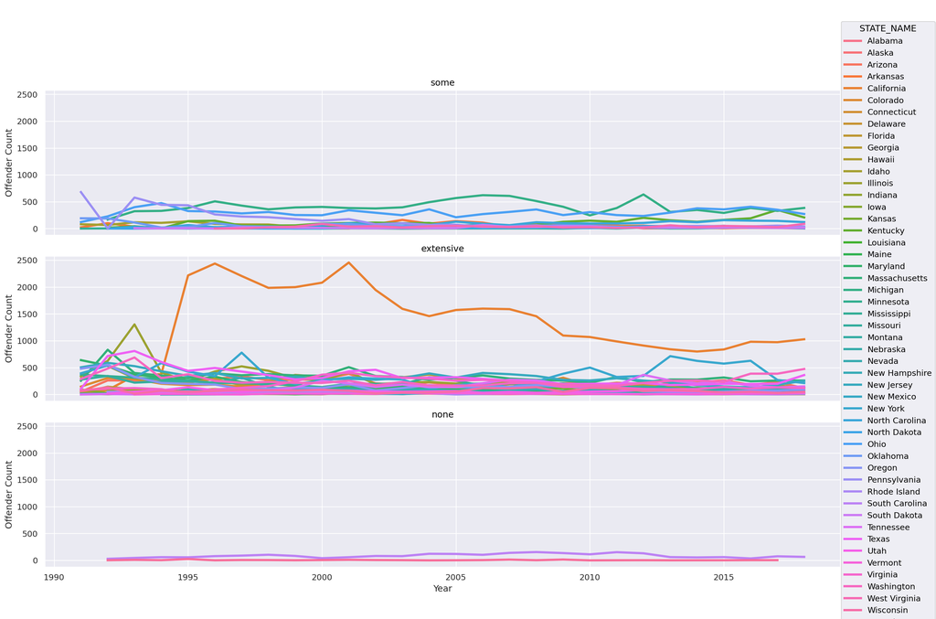

```python
# Adding columns for bias category and legislation extensiveness
hate_crimes_facet = hate_crimes.copy()

# Bias Category
def map_bias_to_category(bias_desc):
    categories = set()
    for bias in bias_desc.split(';'):
        for category, biases in bias_map.items():
            if any(b in bias for b in biases):
                categories.add(category)
    return ';'.join(sorted(categories)) if categories else 'Unknown'

hate_crimes_facet["bias_category"] = hate_crimes['BIAS_DESC'].apply(map_bias_to_category)

# Create Facet Wrapped Graph
# Wrap by legislation extent and graph hate crime counts over time; make a vertical line at when the legislation was implemented

# Group by year and state
hate_crimes_facet_grouped = hate_crimes_facet.groupby(["STATE_NAME", "DATA_YEAR"])["TOTAL_OFFENDER_COUNT"].sum().reset_index()

# Extent of Legislation
hate_crimes_facet_grouped["legislation"] = hate_crimes_facet_grouped['STATE_NAME'].map(legislation_map)

(
    so.Plot(hate_crimes_facet_grouped,
            x = "DATA_YEAR",
            y = "TOTAL_OFFENDER_COUNT",
            color = "STATE_NAME",
            group = "legislation")
    .add(so.Lines(linewidth = 3))
    .facet("legislation", wrap = 1)
    .layout(size = (16, 10))
    .label(x = "Year", y = "Offender Count")
)
```

**Facet-Wrap Analysis:**

Hate crime legislation is widely adopted across both red and blue states, indicating that it is not a partisan issue. Future analysis could incorporate variables such as state population, urban vs. rural distribution, and demographics to further understand these trends and legislative effectiveness.

#### 1.3.3. Most Common Hate Crime Bias Category (Choropleth Map)

The purpose of this visualization is to understand if there is an overwhelming category of hate crime bias in a state and understand what legislation, if any, is in place to help stop that from continuing. This can break down how impactful legislation may be.

```python
# Method:

# 1. Create dataframe to map a state to its most common hate crime bias category and their hate crime proportion using bias categories created during facet map creation
# 2. Create color mapping for each bias category
# 3. Create Choropleth map and map their bias category and proportion

#List most common bias category for each state

#Create a dataframe to map a state to its most common hate crime bias category
StateBiasCategory = pd.DataFrame(columns=['State', 'Most_Common_Bias', 'Proportion'])


for i in list(hate_crimes_facet['STATE_NAME'].unique()):
    topBias = ''
    highestCount = 0

    stateFilteredHateCrimes = hate_crimes_facet[hate_crimes_facet['STATE_NAME'] == i].reset_index()

    for j in list(bias_map.keys()):
        currCount = 0

        for k in range(len(stateFilteredHateCrimes)):
            Currbiases = stateFilteredHateCrimes['bias_category'].values[k].split(";")

            if j in Currbiases:
                currCount += 1

        if currCount > highestCount:
            topBias = j
            highestCount = currCount

    StateBiasCategory.loc[len(StateBiasCategory)] = [i, topBias, highestCount/len(stateFilteredHateCrimes)]

#Choropleth map for bias category

# Define categorical colors
bias_category_colors = {
    "Race/Color": 'blue',
    "National Origin": 'green',
    "Religion": 'red',
    "Sexual Orientation": 'purple',
    "Gender/Sex": 'orange',
    "Gender Identity": 'yellow',
    "Disability": 'pink'
}

# Merge GeoJSON with Data
geo_json_data = json.load(open('us-states.json'))

#Create dictionary mapping
StateBiasMap = StateBiasCategory.set_index('State').to_dict(orient='index')


#create map
m = folium.Map([43, -100], zoom_start=4)

# Function to style each state
def style_function(feature):
    state_name = feature['properties']['name']

    # Retrieve category and proportion
    state_info = StateBiasMap.get(state_name, {})
    category = state_info.get('Most_Common_Bias', None)
    proportion = state_info.get('Proportion', 0)

    # Get color for the category (default to gray if not found)
    fill_color = bias_category_colors.get(category, 'gray')

    return {
        'fillColor': fill_color,
        'color': 'black',
        'weight': 1,
        'fillOpacity': proportion  # Adjust opacity based on proportion
    }

# Add GeoJson layer
folium.GeoJson(
    geo_json_data,
    style_function=style_function,
    tooltip=folium.GeoJsonTooltip(fields=['name'], aliases=['State:'])
).add_to(m)

#add Legend
legend_html = '''
<div style="position: fixed;
            bottom: 40px; left: 40px; width: 200px; height: auto;
            background-color: white; z-index:9999;
            padding: 10px; border-radius: 5px;
            box-shadow: 2px 2px 5px rgba(0,0,0,0.3);
            font-size: 14px; line-height: 18px;">
    <strong>Most Common Bias</strong>
    <hr style="margin:5px 0;">
    <div style="display: flex; flex-direction: column;">
        <div><span style="display:inline-block; width:15px; height:15px; background:blue; margin-right:5px;"></span> Race/Color</div>
        <div><span style="display:inline-block; width:15px; height:15px; background:green; margin-right:5px;"></span> "National Origin"</div>
        <div><span style="display:inline-block; width:15px; height:15px; background:red; margin-right:5px;"></span> Religion</div>
        <div><span style="display:inline-block; width:15px; height:15px; background:purple; margin-right:5px;"></span> Sexual Orientation</div>
        <div><span style="display:inline-block; width:15px; height:15px; background:orange; margin-right:5px;"></span> Gender/Sex</div>
        <div><span style="display:inline-block; width:15px; height:15px; background:yellow; margin-right:5px;"></span> Gender Identity</div>
        <div><span style="display:inline-block; width:15px; height:15px; background:pink; margin-right:5px;"></span> Disability</div>
    </div>
</div>
'''

# Add legend to the map using folium.Element
legend = folium.Element(legend_html)
m.get_root().html.add_child(legend)

# Display the map
m
```

Make this Notebook Trusted to load map: File -> Trust Notebook

[interactive chart not shown]

**Most Common Hate Crime Bias Category Analysis**

The graph shows us that in a vast majority of the states (49/50), the most common hate crime bias category is race/color. This tells us that stricter legislation against race/color biased hate crime is necessary in most states. We can also see that in states with stricter race-based hate crime legislation, there is usually lower percentages of race/color based crimes. This can be seen with the lighter blue color in states such as California when compared to states such as Arkansas and Alabama.

#### 1.3.4. Most Common Hate Crime Bias (Choropleth Map)

The purpose of this visualization is to understand what specific types of hate crime bias are most prevalent in a state.

```python
# Method:

# 1. Explode bias column so each bias is accounter for in case of multiple reported biases
# 2. Count occurrances of each bias per state and determine most common bias and its proportion of total hate crime
# 3. Create Choropleth map to visualize bias and proportion for each US state

# Create an empty DataFrame
StateBiasSpecificCategory = pd.DataFrame(columns=['State', 'Most_Common_Bias', 'Proportion'])

# Extract unique states
unique_states = hate_crimes_facet['STATE_NAME'].unique()

# Process each state
for state in unique_states:
    # Filter data for the current state
    state_data = hate_crimes_facet[hate_crimes_facet['STATE_NAME'] == state]

    # Explode BIAS_DESC values to count individual biases
    exploded_biases = state_data.assign(BIAS_DESC=state_data['BIAS_DESC'].str.split(";")).explode('BIAS_DESC')

    # Count occurrences of each bias
    bias_counts = exploded_biases['BIAS_DESC'].value_counts()

    # Get the most common bias and its count
    top_bias = bias_counts.idxmax()
    highest_count = bias_counts.max()

    # Calculate proportion
    proportion = highest_count / len(state_data)

    # Append results
    StateBiasSpecificCategory = pd.concat([StateBiasSpecificCategory,
                                           pd.DataFrame([[state, top_bias, proportion]],
                                                        columns=['State', 'Most_Common_Bias', 'Proportion'])],
                                          ignore_index=True)

#Choropleth map for specific bias category

# Define categorical colors
specific_bias_category_colors = {
    "Anti-American Indian or Alaska Native": 'blue',
    "Anti-Black or African American": 'green',
    "Anti-White": 'red',
    "Anti-Physical Disability": 'purple',
    "Anti-Jewish": 'orange',
}

# Merge GeoJSON with Data
geo_json_data = json.load(open('us-states.json'))

#Create dictionary mapping
StateSpecificBiasMap = StateBiasSpecificCategory.set_index('State').to_dict(orient='index')


#create map
m = folium.Map([43, -100], zoom_start=4)

# Function to style each state
def style_function(feature):
    state_name = feature['properties']['name']

    # Retrieve category and proportion
    state_info = StateSpecificBiasMap.get(state_name, {})
    category = state_info.get('Most_Common_Bias', None)
    proportion = state_info.get('Proportion', 0)

    # Get color for the category (default to gray if not found)
    fill_color = specific_bias_category_colors.get(category, 'gray')

    return {
        'fillColor': fill_color,
        'color': 'black',
        'weight': 1,
        'fillOpacity': proportion  # Adjust opacity based on proportion
    }

# Add GeoJson layer
folium.GeoJson(
    geo_json_data,
    style_function=style_function,
    tooltip=folium.GeoJsonTooltip(fields=['name'], aliases=['State:'])
).add_to(m)

#add Legend
legend_html = '''
<div style="position: fixed;
            bottom: 40px; left: 40px; width: 200px; height: auto;
            background-color: white; z-index:9999;
            padding: 10px; border-radius: 5px;
            box-shadow: 2px 2px 5px rgba(0,0,0,0.3);
            font-size: 14px; line-height: 18px;">
    <strong>Most Common Bias</strong>
    <hr style="margin:5px 0;">
    <div style="display: flex; flex-direction: column;">
        <div><span style="display:inline-block; width:15px; height:15px; background:blue; margin-right:5px;"></span> Anti-American Indian or Alaska Native</div>
        <div><span style="display:inline-block; width:15px; height:15px; background:green; margin-right:5px;"></span> "Anti-Black or African American"</div>
        <div><span style="display:inline-block; width:15px; height:15px; background:red; margin-right:5px;"></span> Anti-White</div>
        <div><span style="display:inline-block; width:15px; height:15px; background:purple; margin-right:5px;"></span> Anti-Physical Disability</div>
        <div><span style="display:inline-block; width:15px; height:15px; background:orange; margin-right:5px;"></span> Anti-Jewish</div>
    </div>
</div>
'''

# Add legend to the map using folium.Element
legend = folium.Element(legend_html)
m.get_root().html.add_child(legend)

# Display the map
m
```

Make this Notebook Trusted to load map: File -> Trust Notebook

[interactive chart not shown]

**Most Common Hate Crime Bias (Specific) Analysis**

With this visualization we are able to go further in depth upon what was built in the previous visualization. We can see which races in particular were targeted most, which in most cases the was Black or African American Race. We also do find 5 unique top biases which is much more insightful than previously with the categories.

## Part 2: Modeling

#### 2.1. Multinomial Logstic Regression

This model predicts which bias categories are protected by a state's hate crime legislation, aiming to identify key features that inform these protections. The goal is to help states consider relevant factors when defining hate crime legislation and determine which bias categories should be prioritized for victim protection. We are using a Multinomial Logstic Regression to be able to predict the outcome of multiple variables (the different `Bias_Categories` in the dataset) in the dataset. Ie. predicting which `Bias_Categories` are protected within a given state's hate crime legislation conditioned on a set number of features defined in the code cell below.

```python
# 3.1.a. Data Manipulation: Creating a dataframe for Multinomial Logistic Regression
# Merging bias category data table with `hate_crimes` datatable
merged = pd.merge(hate_crimes, hc_leg_state,
                  how = "left",
                  left_on = "STATE_NAME", right_on = "State")

# Determining our target variables to predict in our Multinomial Logistic Regression
targets = merged[['STATE_NAME', 'Race/Color', 'National Origin', 'Religion', 'Sexual Orientation', 'Gender/Sex', 'Gender Identity', 'Disability']]
target_features = merged[['Race/Color', 'National Origin', 'Religion', 'Sexual Orientation', 'Gender/Sex', 'Gender Identity', 'Disability']]
target_cols = ['Race/Color', 'National Origin', 'Religion', 'Sexual Orientation', 'Gender/Sex', 'Gender Identity', 'Disability']

# Dummy variables of `BIAS_DESC`
bias_counts = pd.get_dummies(merged['BIAS_DESC']).groupby(merged['STATE_NAME']).sum().reset_index()

# Counts of our target variables
target_counts = targets.groupby("STATE_NAME").sum()


# Feature Selection
features_MLR = ["AGENCY_TYPE_NAME", "POPULATION_GROUP_DESC", "OFFENSE_NAME", "Bias_Category", "VICTIM_COUNT", "REGION_NAME"]


# Data Table Engineering
state_data = merged.groupby("STATE_NAME").agg({
    "AGENCY_TYPE_NAME": lambda x: x.mode()[0],
    "POPULATION_GROUP_DESC": lambda x: x.mode()[0],
    "OFFENSE_NAME": lambda x: x.mode()[0],
    "Bias_Category": lambda x: x.mode()[0],
    "VICTIM_COUNT": "mean",
    "REGION_NAME": lambda x: x.mode()[0]
}).reset_index()

# Merge with legislation targets
state_data = pd.merge(
    state_data,
    hc_leg_state,
    left_on = "STATE_NAME",
    right_on = "State"
).drop(columns=['State'])

state_data[target_cols] = state_data[target_cols].fillna(False).infer_objects(copy=False).astype(int)


preprocessor = ColumnTransformer(
    transformers=[
        ('onehot', OneHotEncoder(handle_unknown='ignore'), [
            'AGENCY_TYPE_NAME',
            'POPULATION_GROUP_DESC',
            'OFFENSE_NAME',
            'Bias_Category',
            'REGION_NAME'
        ])
    ],
    remainder='drop'
)
X = preprocessor.fit_transform(state_data)
y = state_data[target_cols].astype(int)


# Split data
X_train, X_test, y_train, y_test = train_test_split(
    X, y, test_size = 0.2, random_state = 42
)

# Train model
model = MultiOutputClassifier(
    LogisticRegression(solver = 'lbfgs', max_iter = 1000)
).fit(X_train, y_train)


# Predicting our data
y_pred = model.predict(X_test)

# Accuracy
accuracy = accuracy_score(y_test, y_pred, normalize=True)
print(f"Overall Accuracy: {accuracy:.2f}")

# Model Report
print(classification_report(y_test, y_pred, target_names=target_cols))
```

```
Overall Accuracy: 0.30
                    precision    recall  f1-score   support

        Race/Color       0.90      1.00      0.95         9
   National Origin       0.90      1.00      0.95         9
          Religion       0.90      1.00      0.95         9
Sexual Orientation       0.75      0.75      0.75         8
        Gender/Sex       0.80      1.00      0.89         8
   Gender Identity       0.00      0.00      0.00         2
        Disability       0.67      0.86      0.75         7

         micro avg       0.82      0.90      0.86        52
         macro avg       0.70      0.80      0.75        52
      weighted avg       0.80      0.90      0.85        52
       samples avg       0.83      0.82      0.82        52
```

**Multinomial Logistic Regression Analysis:**

The model performs well for most bias categories, with high precision, recall, and F1-scores (0.75–0.95) for common categories like “Race/Color” and “Religion.” However, it fails to predict rare categories like “Gender Identity” (0.00 scores), significantly lowering overall accuracy (30%), highlighting challenges in imbalanced multi-label classification.

#### 2.2. Logistic Regression for Predicting State of Hate Crime Occurrence

The purpose of this model was to try and predict the state in which a particular hate crime occurred. This is insightful because it can provide understanding of what might drive certain hate crimes in one state over another.

```python
Model2DF = hate_crimes.drop(columns = ['ORI', 'PUB_AGENCY_NAME', 'INCIDENT_ID', 'STATE_NAME', 'POPULATION_GROUP_CODE', 'DIVISION_NAME', 'REGION_NAME', 'DATA_YEAR', 'Bias_Category', 'Legislation_Level'], axis = 1)

#create incident month column and then drop incient date column
Model2DF['INCIDENT_DATE'] = pd.to_datetime(Model2DF['INCIDENT_DATE'])
Model2DF
Model2DF['INCIDENT_MONTH'] = Model2DF['INCIDENT_DATE'].dt.month

Model2DF = Model2DF.drop('INCIDENT_DATE', axis = 1)

#Create Dummy variables for categorical variables: 'DATA_YEAR', 'AGENCY_TYPE_NAME', 'STATE_ABBR', 'DIVISION_NAME', 'REGION_NAME', 'POPULATION_GROUP_DESC', 'OFFENDER_RACE', 'OFFENSE_NAME', 'LOCATION_NAME', 'BIAS_DESC', 'VICTIM_TYPES', 'MULTIPLE_OFFENSE', 'MULTIPLE_BIAS', 'INCIDENT_MONTH'

Model2DF = pd.get_dummies(Model2DF, columns = ['AGENCY_TYPE_NAME', 'POPULATION_GROUP_DESC', 'OFFENDER_RACE', 'MULTIPLE_OFFENSE', 'MULTIPLE_BIAS', 'INCIDENT_MONTH'], drop_first=True)

### different handling for remaining columns bc multiple entries per row
#Create separate labels for each entry in 'BIAS_DESC', 'VICTIM_TYPES', 'OFFENSE_NAME', AND 'LOCATION_NAME'

#Turn string columns into lists of entries
Model2DF['BIAS_DESC'] = Model2DF['BIAS_DESC'].str.split(';')
Model2DF['VICTIM_TYPES'] = Model2DF['VICTIM_TYPES'].str.split(';')
Model2DF['OFFENSE_NAME'] = Model2DF['OFFENSE_NAME'].str.split(';')
Model2DF['LOCATION_NAME'] = Model2DF['LOCATION_NAME'].str.split(';')

#import package
from sklearn.preprocessing import MultiLabelBinarizer

#initialize object
mlb = MultiLabelBinarizer()

#list to hold one-hot encoded DataFrames
encoded_dfs = []

#iterate through each column you want to one-hot encode
for col in ['BIAS_DESC', 'VICTIM_TYPES', 'OFFENSE_NAME', 'LOCATION_NAME']:
    mlb = MultiLabelBinarizer()
    encoded = pd.DataFrame(
        mlb.fit_transform(Model2DF[col]),
        columns=[f"{col}_{cls}" for cls in mlb.classes_],
        index=Model2DF.index)
    encoded_dfs.append(encoded)

#Concatenate all one-hot encoded columns with original DataFrame
Model2DF = pd.concat([Model2DF] + encoded_dfs, axis=1)

#drop all 4 original columns:
Model2DF = Model2DF.drop(columns = ['BIAS_DESC', 'VICTIM_TYPES', 'OFFENSE_NAME', 'LOCATION_NAME'], axis = 1)


#create X and y sets
X = Model2DF.drop('STATE_ABBR', axis = 1)
y = Model2DF['STATE_ABBR']

#scale x set
scaler = StandardScaler()
X_scaled = scaler.fit_transform(X)

X_train, X_test, y_train, y_test = train_test_split(X_scaled, y, test_size=0.2, random_state=42)

model = LogisticRegression(multi_class='multinomial', solver='lbfgs', max_iter=500)
model.fit(X_train, y_train)

y_pred = model.predict(X_test)
print(classification_report(y_test, y_pred))
```

```
/tmp/ipykernel_85/518876492.py:9: UserWarning: Could not infer format, so each element will be parsed individually, falling back to `dateutil`. To ensure parsing is consistent and as-expected, please specify a format.
  Model2DF['INCIDENT_DATE'] = pd.to_datetime(Model2DF['INCIDENT_DATE'])
/root/venv/lib/python3.10/site-packages/sklearn/linear_model/_logistic.py:1247: FutureWarning: 'multi_class' was deprecated in version 1.5 and will be removed in 1.7. From then on, it will always use 'multinomial'. Leave it to its default value to avoid this warning.
  warnings.warn(
/root/venv/lib/python3.10/site-packages/sklearn/metrics/_classification.py:1565: UndefinedMetricWarning: Precision is ill-defined and being set to 0.0 in labels with no predicted samples. Use `zero_division` parameter to control this behavior.
  _warn_prf(average, modifier, f"{metric.capitalize()} is", len(result))
              precision    recall  f1-score   support

          AK       0.20      0.14      0.17        35
          AL       0.00      0.00      0.00        42
          AR       0.31      0.05      0.09       241
          AZ       0.49      0.05      0.09      1222
          CA       0.32      0.76      0.45      6669
          CO       0.09      0.02      0.03       766
          CT       0.44      0.08      0.13       728
          DE       0.35      0.13      0.19       206
          FL       0.28      0.13      0.18       983
          GA       0.06      0.01      0.01       173
          HI       0.33      0.25      0.29         8
          IA       0.00      0.00      0.00       172
          ID       0.13      0.02      0.04       248
          IL       0.32      0.06      0.10      1062
          IN       0.12      0.01      0.01       384
          KS       0.23      0.04      0.07       335
          KY       0.37      0.13      0.19       602
          LA       0.32      0.10      0.16        96
          MA       0.31      0.31      0.31      2105
          MD       0.42      0.55      0.47      1135
          ME       0.10      0.03      0.04       228
          MI       0.22      0.36      0.27      2282
          MN       0.30      0.21      0.25       910
          MO       0.20      0.12      0.15       593
          MS       0.20      0.13      0.16        31
          MT       0.11      0.03      0.05       131
          NB       0.08      0.01      0.01       173
          NC       0.15      0.01      0.03       416
          ND       0.44      0.15      0.22        74
          NH       0.00      0.00      0.00       121
          NJ       0.46      0.84      0.59      3614
          NM       0.10      0.01      0.02       105
```

[output cut: 12 more lines]

```
          VA       0.28      0.19      0.23      1036
          VT       0.64      0.09      0.16       101
          WA       0.23      0.04      0.06      1484
          WI       0.30      0.01      0.02       291
          WV       0.26      0.04      0.07       185
          WY       0.00      0.00      0.00        32

    accuracy                           0.38     39695
   macro avg       0.24      0.13      0.14     39695
weighted avg       0.34      0.38      0.31     39695

/root/venv/lib/python3.10/site-packages/sklearn/metrics/_classification.py:1565: UndefinedMetricWarning: Precision is ill-defined and being set to 0.0 in labels with no predicted samples. Use `zero_division` parameter to control this behavior.
  _warn_prf(average, modifier, f"{metric.capitalize()} is", len(result))
/root/venv/lib/python3.10/site-packages/sklearn/metrics/_classification.py:1565: UndefinedMetricWarning: Precision is ill-defined and being set to 0.0 in labels with no predicted samples. Use `zero_division` parameter to control this behavior.
  _warn_prf(average, modifier, f"{metric.capitalize()} is", len(result))
```

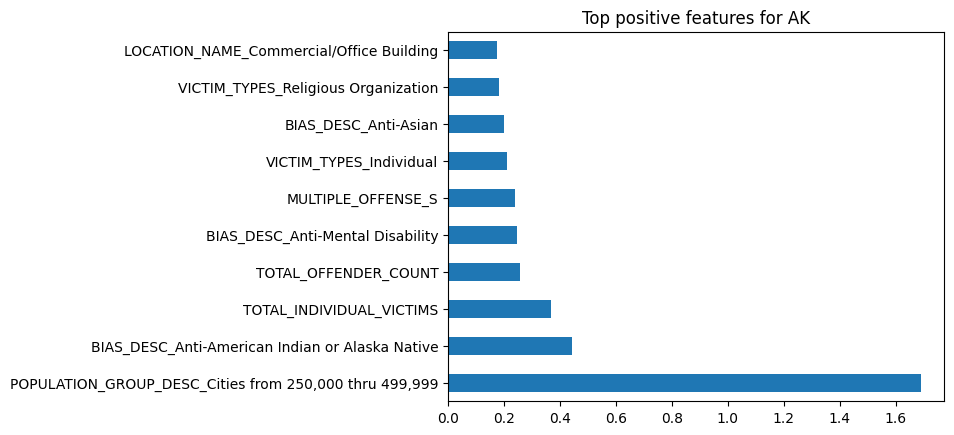

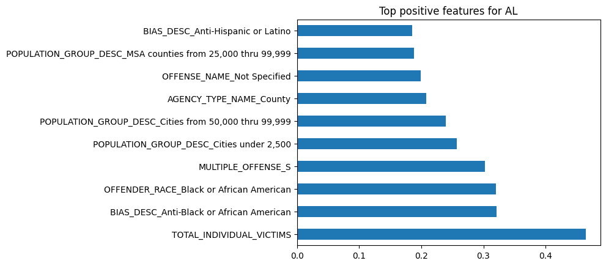

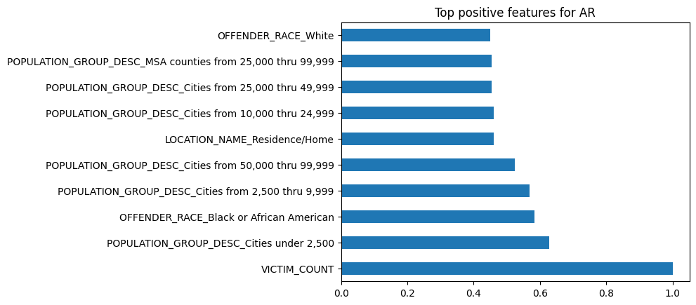

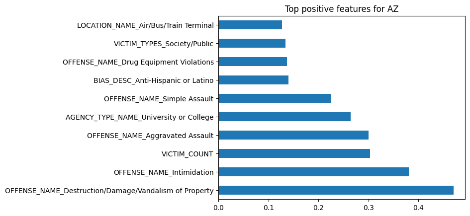

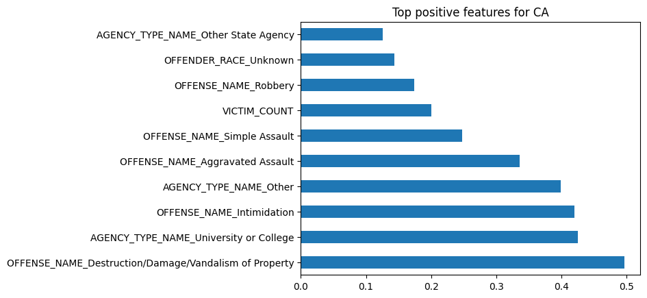

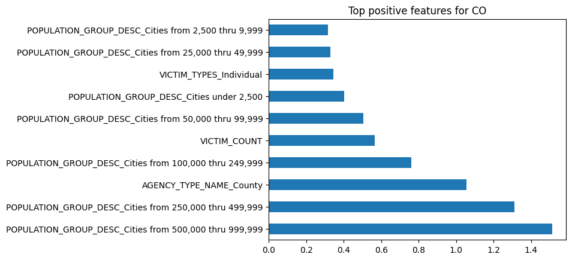

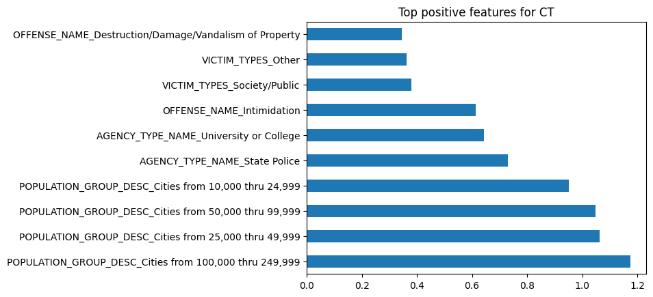

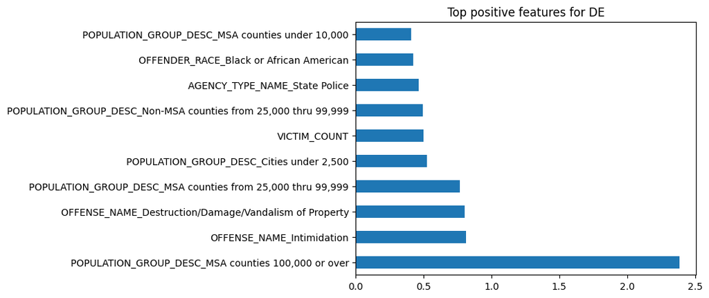

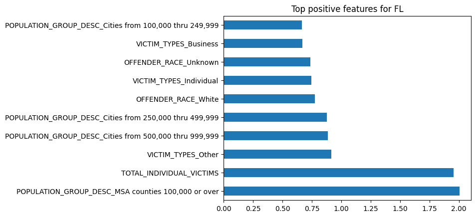

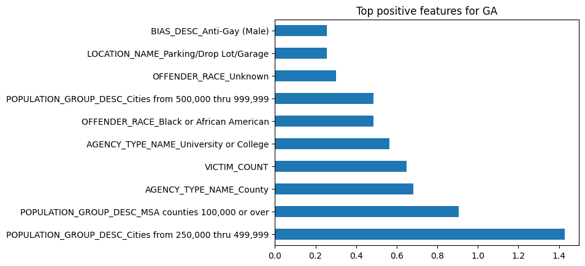

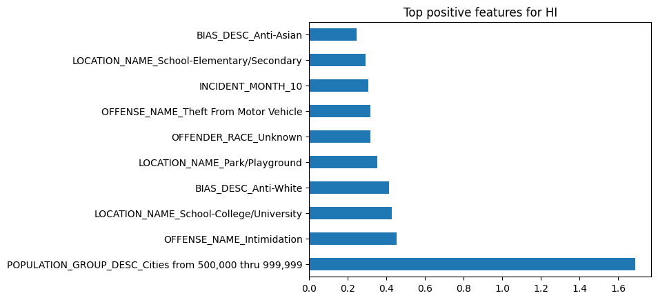

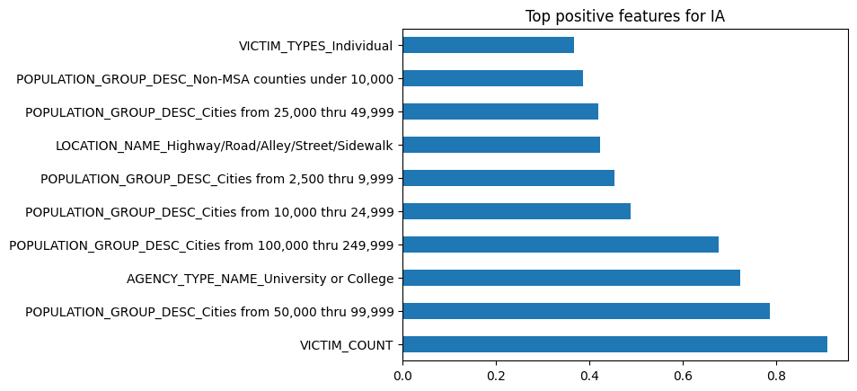

[38 more figures not shown]

```python
#Understand which features help point towards each specific state

#get class labels
class_labels = model.classes_

#convert coefficients matrix to DataFrame
coef_df = pd.DataFrame(model.coef_, columns=X.columns, index=class_labels)

#store top features per state
top_features = {}

for state in coef_df.index:
    top = coef_df.loc[state].sort_values(ascending=False).head(10)
    top_features[state] = top

#Make graphs to showcase level of correlation
for state in class_labels:
    coef_df.loc[state].sort_values(ascending=False).head(10).plot(kind='barh')
    plt.title(f"Top positive features for {state}")
    plt.show()
```

#### 2.3. Random Forest for predicting types of bias

Although random forest is less interpretable, I want to use it to captures complex nonlinear interactions between features (e.g., how state and population group jointly influence outcomes). Also I can see if there's potential biases across different motivations in my model which may have broader impacts in similar models.

```python
# Predictor and target columns
predictors = [
    'DATA_YEAR',
    'STATE_NAME',
    'legislation',
    'OFFENSE_TYPE',
    'POPULATION_GROUP_DESC',
    'TOTAL_OFFENDER_COUNT',
    'OFFENDER_RACE',
    'VICTIM_COUNT',
    'TOTAL_INDIVIDUAL_VICTIMS',
    'VICTIM_TYPES',
    'MULTIPLE_OFFENSE'
]

target = 'bias_category'

# Drop rows with missing target
model3DF = model3DF.dropna(subset=[target])

# Split into X and y
X = model3DF[predictors]
y = model3DF[target]

# Identify categorical vs numeric features
categorical_features = X.select_dtypes(include='object').columns.tolist()
numeric_features = X.select_dtypes(exclude='object').columns.tolist()

# Preprocessing pipeline
preprocessor = ColumnTransformer(
    transformers=[
        ('cat', OneHotEncoder(handle_unknown='ignore'), categorical_features)
    ],
    remainder='passthrough'  # keep numeric columns as-is
)

# Final modeling pipeline
pipeline = Pipeline([
    ('preprocess', preprocessor),
    ('clf', RandomForestClassifier(n_estimators=100, random_state=42))
])
# Define the categories you want to keep
valid_categories = [
    'Race/Color', 'Religion', 'Sexual Orientation',
    'Disability', 'Gender Identity', 'Gender/Sex'
]

# Filter the y (bias_category) to only include the valid categories
y_filtered = y[y.isin(valid_categories)]

# Now, apply this filter to X to keep the corresponding rows in the dataset
X_filtered = X[y.isin(valid_categories)]

# Proceed with the train-test split
X_train, X_test, y_train, y_test = train_test_split(
    X_filtered, y_filtered, test_size=0.2, stratify=y_filtered, random_state=42
)

# Now you can continue with training your model as before
pipeline.fit(X_train, y_train)


# Evaluate
y_pred = pipeline.predict(X_test)
print(classification_report(y_test, y_pred))


clf = pipeline.named_steps['clf']
importances = clf.feature_importances_

# Feature names
ohe = pipeline.named_steps['preprocess'].named_transformers_['cat']
feature_names = ohe.get_feature_names_out(categorical_features)
all_features = np.concatenate([feature_names, numeric_features])

# Show top important features
feature_importance_df = pd.DataFrame({
    'feature': all_features,
    'importance': importances
}).sort_values(by='importance', ascending=False)

print(feature_importance_df.head(10))
```

```
                    precision    recall  f1-score   support

        Disability       0.33      0.13      0.18       311
   Gender Identity       0.21      0.07      0.11       111
        Gender/Sex       0.00      0.00      0.00        47
        Race/Color       0.71      0.84      0.77     25700
          Religion       0.55      0.41      0.47      7280
Sexual Orientation       0.32      0.18      0.23      6208

          accuracy                           0.65     39657
         macro avg       0.35      0.27      0.29     39657
      weighted avg       0.61      0.65      0.62     39657

                                 feature  importance
163                            DATA_YEAR    0.397242
164                 TOTAL_OFFENDER_COUNT    0.079863
166             TOTAL_INDIVIDUAL_VICTIMS    0.035463
156  VICTIM_TYPES_Religious Organization    0.035107
144              VICTIM_TYPES_Individual    0.026966
165                         VICTIM_COUNT    0.021780
113                OFFENDER_RACE_Unknown    0.021291
31                   STATE_NAME_New York    0.018832
78           OFFENSE_TYPE_Property Crime    0.016427
86            OFFENSE_TYPE_Violent Crime    0.013803
```

**Results for random forest model:**

| Class | Precision | Recall | F1-score | Support |
| --- | --- | --- | --- | --- |
| Disability | 0.33 | 0.13 | 0.18 | 311 |
| GenderIdentity | 0.21 | 0.07 | 0.11 | 111 |
| Gender(Sex) | 0.00 | 0.00 | 0.00 | 47 |
| Race(Color) | 0.71 | 0.84 | 0.77 | 25,700 |
| Religion | 0.55 | 0.41 | 0.47 | 7,280 |
| SexualOrientation | 0.32 | 0.18 | 0.23 | 6,208 |

**Accuracy**: 0.65 (out of 39,657 total samples)  
**Macro avg**: Precision = 0.35, Recall = 0.27, F1-score = 0.29  
**Weighted avg**: Precision = 0.61, Recall = 0.65, F1-score = 0.62

**Conclusion for random forest method:**

The model performs very well on "Race/Color", which dominates the dataset. However, we can see that for a case with gender identity, gender sex bias as the key motivations behind, since we have less data, it might be easier to misclassify and that means we should be concerned when this happen in the real-life criminal settings that a model trained on imbalanced dataset may lead to biased results.

#### 2.4. Logistic regression for predicting types of bias

This model may have lower precision compared to the random forest model since the motivation behind a hate crime is a very complex and nuanced thing and there might be some non-linear relationships and interaction variables needed to take into account. However, we wanted to model it using logistic regression since it is very interpretable and can possibly provide some meaningful insights.

```python
model_data = hate_crimes.copy()

categories = {
    "Violent Crime": [
        "Aggravated Assault", "Simple Assault", "Intimidation", "Murder and Nonnegligent Manslaughter",
        "Negligent Manslaughter", "Kidnapping/Abduction", "Robbery", "Rape", "Sodomy",
        "Sexual Assault With An Object", "Fondling", "Incest", "Statutory Rape", "Purse-snatching"
    ],
    "Property Crime": [
        "Burglary/Breaking & Entering", "Destruction/Damage/Vandalism of Property", "Arson",
        "Theft From Motor Vehicle", "Theft From Building", "Motor Vehicle Theft", "Shoplifting",
        "Theft of Motor Vehicle Parts or Accessories", "All Other Larceny", "Pocket-picking",
        "Theft From Coin-Operated Machine or Device", "Stolen Property Offenses"
    ],
    "Drug Offense": [
        "Drug/Narcotic Violations", "Drug Equipment Violations"
    ],
    "Weapon Offense": [
        "Weapon Law Violations"
    ],
    "Sex Offense": [
        "Rape", "Fondling", "Sodomy", "Incest", "Statutory Rape", "Pornography/Obscene Material"
    ],
    "Fraud": [
        "Credit Card/Automated Teller Machine Fraud", "False Pretenses/Swindle/Confidence Game",
        "Welfare Fraud", "Embezzlement", "Counterfeiting/Forgery", "Wire Fraud"
    ],
    "Impersonation": [
        "Impersonation"
    ],
    "Extortion/Blackmail": [
        "Extortion/Blackmail"
    ],
    "Other": [
        "Prostitution", "Not Specified"
    ]
}

offense_to_category = {}
for cat, offenses in categories.items():
    for o in offenses:
        offense_to_category[o] = cat

def map_offense_type(offense_str):
    offense_list = [o.strip() for o in offense_str.split(";")]
    category_set = set()
    for offense in offense_list:
        category_set.add(offense_to_category.get(offense, "Other"))
    return ";".join(sorted(category_set))

model_data['OFFENSE_TYPE'] = model_data['OFFENSE_NAME'].apply(map_offense_type)
model_data["bias_category"] = model_data['BIAS_DESC'].apply(map_bias_to_category)
model_data["legislation"] = model_data['STATE_NAME'].map(legislation_map)

# map victim type
# Define mapping for individual types only
base_type_map = {
    "Individual": "Individual",
    "Religious Organization": "Religious Org",
    "Society/Public": "Society/Public",
    "Business": "Business",
    "Government": "Government",
    "Other": "Other",
    "Unknown": "Unknown",
    "Financial Institution": "Financial Institution",
    "Law Enforcement Officer": "Law Enforcement"
}

def normalize_victim_types(victim_str):
    if pd.isnull(victim_str):
        return "Unknown"
    parts = [v.strip() for v in victim_str.split(";")]
    mapped_parts = [base_type_map.get(p, p) for p in parts]
    return ";".join(sorted(set(mapped_parts)))

# Apply to your DataFrame
model_data["VICTIM_CATEGORY"] = model_data["VICTIM_TYPES"].apply(normalize_victim_types)


##logistic regression:
import pandas as pd
from sklearn.model_selection import train_test_split
from sklearn.preprocessing import OneHotEncoder
from sklearn.compose import ColumnTransformer
from sklearn.pipeline import Pipeline
from sklearn.linear_model import LogisticRegression
from sklearn.metrics import classification_report

# Predictor and target columns
predictors = [
    'DATA_YEAR',
    'STATE_NAME',
    'legislation',
    'OFFENSE_TYPE',
    'POPULATION_GROUP_DESC',
    'TOTAL_OFFENDER_COUNT',
    'OFFENDER_RACE',
    'VICTIM_COUNT',
    'TOTAL_INDIVIDUAL_VICTIMS',
    'VICTIM_TYPES',
    'MULTIPLE_OFFENSE'
]

target = 'bias_category'

# Drop rows with missing target
model_data = model_data.dropna(subset=[target])

# Split into X and y
X = model_data[predictors]
y = model_data[target]

# Identify categorical vs numeric features
categorical_features = X.select_dtypes(include='object').columns.tolist()
numeric_features = X.select_dtypes(exclude='object').columns.tolist()

# Preprocessing pipeline
preprocessor = ColumnTransformer(
    transformers=[
        ('cat', OneHotEncoder(handle_unknown='ignore'), categorical_features)
    ],
    remainder='passthrough'  # keep numeric columns as-is
)

# Final modeling pipeline with Logistic Regression
pipeline = Pipeline([
    ('preprocess', preprocessor),
    ('clf', LogisticRegression(max_iter=1000, multi_class='multinomial', solver='lbfgs'))
])

# Keep only valid categories
valid_categories = [
    'Race/Color', 'Religion', 'Sexual Orientation',
    'Disability', 'Gender Identity', 'Gender/Sex'
]
y_filtered = y[y.isin(valid_categories)]
X_filtered = X[y.isin(valid_categories)]

# Train-test split
X_train, X_test, y_train, y_test = train_test_split(
    X_filtered, y_filtered, test_size=0.2, stratify=y_filtered, random_state=42
)

# Train model
pipeline.fit(X_train, y_train)

# Predict and evaluate
y_pred = pipeline.predict(X_test)
import numpy as np

# Get the model and feature names
clf = pipeline.named_steps['clf']
ohe = pipeline.named_steps['preprocess'].named_transformers_['cat']
feature_names = ohe.get_feature_names_out(categorical_features)
all_features = np.concatenate([feature_names, numeric_features])

# Get coefficients for each class
for i, class_label in enumerate(clf.classes_):
    print(f"\nTop predictors for class: {class_label}")
    class_coefs = clf.coef_[i]
    top_idx = np.argsort(class_coefs)[-10:]  # top 10
    for idx in reversed(top_idx):
        print(f"{all_features[idx]}: {class_coefs[idx]:.4f}")
```

```
/root/venv/lib/python3.10/site-packages/sklearn/linear_model/_logistic.py:1247: FutureWarning: 'multi_class' was deprecated in version 1.5 and will be removed in 1.7. From then on, it will always use 'multinomial'. Leave it to its default value to avoid this warning.
  warnings.warn(

Top predictors for class: Disability
legislation_some: 0.0695
TOTAL_OFFENDER_COUNT: 0.0442
STATE_NAME_Ohio: 0.0422
OFFENDER_RACE_Black or African American: 0.0224
POPULATION_GROUP_DESC_Cities from 10,000 thru 24,999: 0.0218
VICTIM_TYPES_Individual: 0.0208
POPULATION_GROUP_DESC_Non-MSA counties from 25,000 thru 99,999: 0.0197
STATE_NAME_Tennessee: 0.0183
OFFENDER_RACE_White: 0.0169
STATE_NAME_South Carolina: 0.0158

Top predictors for class: Gender Identity
TOTAL_OFFENDER_COUNT: 0.0373
STATE_NAME_Massachusetts: 0.0203
OFFENDER_RACE_Black or African American: 0.0175
POPULATION_GROUP_DESC_Cities from 500,000 thru 999,999: 0.0118
OFFENSE_TYPE_Violent Crime: 0.0100
legislation_extensive: 0.0100
POPULATION_GROUP_DESC_Cities from 50,000 thru 99,999: 0.0094
VICTIM_TYPES_Individual: 0.0092
STATE_NAME_Washington: 0.0080
POPULATION_GROUP_DESC_Cities 1,000,000 or over: 0.0058

Top predictors for class: Gender/Sex
TOTAL_INDIVIDUAL_VICTIMS: 0.0106
STATE_NAME_Massachusetts: 0.0082
OFFENDER_RACE_White: 0.0065
legislation_some: 0.0054
STATE_NAME_Virginia: 0.0044
STATE_NAME_Michigan: 0.0042
POPULATION_GROUP_DESC_MSA counties from 10,000 thru 24,999: 0.0039
VICTIM_TYPES_Individual: 0.0038
VICTIM_COUNT: 0.0035
STATE_NAME_Washington: 0.0034

Top predictors for class: Race/Color
```

[output cut: 27 more lines]

```
OFFENSE_TYPE_Violent Crime: 0.1865
POPULATION_GROUP_DESC_Cities under 2,500: 0.1361
OFFENDER_RACE_Black or African American: 0.1116
TOTAL_INDIVIDUAL_VICTIMS: 0.1085
POPULATION_GROUP_DESC_Cities 1,000,000 or over: 0.0779
legislation_extensive: 0.0709
OFFENDER_RACE_Multiple: 0.0521
/root/venv/lib/python3.10/site-packages/sklearn/linear_model/_logistic.py:465: ConvergenceWarning: lbfgs failed to converge (status=1):
STOP: TOTAL NO. of ITERATIONS REACHED LIMIT.

Increase the number of iterations (max_iter) or scale the data as shown in:
    https://scikit-learn.org/stable/modules/preprocessing.html
Please also refer to the documentation for alternative solver options:
    https://scikit-learn.org/stable/modules/linear_model.html#logistic-regression
  n_iter_i = _check_optimize_result(
```

**Conclusion for the logistic regression model:**

The logistic regression analysis reveals that different types of bias-related hate crimes exhibit distinct geographic, demographic, and situational patterns. For Disability and Religion, the presence or absence of state legislation and the specific state itself (e.g., Ohio, New York) are strong predictors. This suggests that both reporting practices and classification may vary by jurisdictional policy environments. Race/Color, Religion, and Sexual Orientation biases are strongly associated with urban population centers and institutional or individual targets. In contrast, Disability bias appears more frequently in smaller towns or less urbanized regions.

## Part 3: Conclusion

### 3.1. Conclusion

#### Next Steps

Next steps include using more granular state-level legislation data to clarify legislative impacts on hate crime rates. Additionally, refactoring the dataset and samplying specific cases to emphasize could improve the accuracy of our models. As we explore the impact of legislation on hate crimes, we may identify key legislation types, though this could shift focus away from other hate crime biases.

#### Gaps

Overall, our models tended to perform well on common bias categories, especially 'Race/Color', but struggled with underrepresented ones like 'Gender Identity'. This was a recurring trend across our models, so moving forward we will definitely have to account for class imbalance for more accurate models. Outside of this, predictions were frequently influenced by certain states, urban levels, and victim types. These may not be some of the strongest predictors which raises concerns about the feature importances that the models picked up on. Another gap would be in understanding when specific hate crime legislation was passed in a state so that we can further understand legislation importance. Also, since we are looking at historical hate crime data, lots of hate crimes go unreported in the dataset which can cause our results to be different than what is shown in the real world.

#### Ethical Considerations

By targeting one specific type of hate crime, all other types of hate crime might be neglected, which is an ethical consideration that should be taken into account in understanding this project. Also, since we are looking into hate crime data, it is important to consider the risk of reinforcing bias within the data and not make already vulnerable groups even worse off.

#### Methodologies Discussion

Our methods effectively addressed the research question. Including a broader range of bias categories, legislation levels, and victim types helped us better understand how state laws influence the types of hate crimes committed. Additionally, the diversity of models used ensured that the models analyzed diverse aspects of our question, culminating in a nuanced understanding of our goal.